# Preliminary analysis on creel -irec calibration model

Catarina Wor, Sean Anderson, Rob Houtman

April 2022

# 1 Rationale

Develop a calibration model to combine both creel and irec survey methods to a single recreational catch estimate, taking into account month and area. This is an update to the current calibration method that produces coastwide and year-long estimates.

# 2 Data groupings decisions

# 3 Current calibration model

The current calibration model is of the form:

$$\begin{align}
&iREC_i = \beta_1\cdot z_i + \epsilon_i\\
&z_i = Creel_i + \nu_{i}
\end{align}$$

We believe that, for the purposes of the calibration model , it would be better to flip the explanatory and response variables. This way the model would produce calibrated creel estimates, not calibrated irec estimates. Therefore we consider the following base model:

$$\begin{align}
&Creel_i = \beta_1\cdot z_i + \epsilon_i\\
&z_i = iREC_i + \nu_{i}
\end{align}$$

$$\begin{align}
&\epsilon_i \sim N(0,\sigma_{\epsilon})\\
&\nu_{i} \sim N(0,\sigma_{\nu})
\end{align}$$

where:

$iREC_i$ = iREC observation

$Creel_i$ = creel observation

$\beta_1$ = slope associated with $iREC_i$

$z_i$ = smoothed (‘true’) $iREC_i$

$\epsilon_i$ and $\nu_{i}$ are normally distributed error

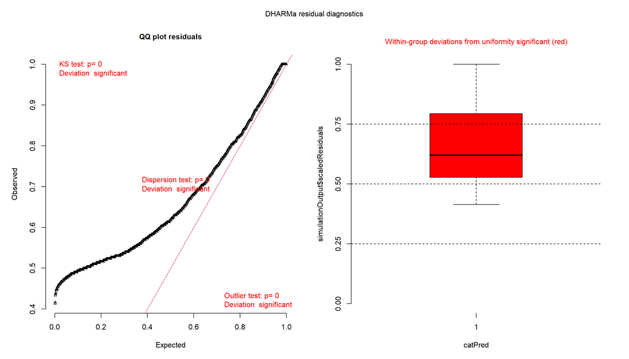

Figure 3.1: DHARMa Residual plots for the base calibration model

# 4 Alternative calibration model

The objective of this alternative model is to include the effect of area and month in the calibration model to account for spatial and temporal variation in the relationship between creel and irec.

We found that including a non-zero intercept in the model led to an improved model fit.

We opted for using a polynomial smoothing function over the variable month instead of the season covariate as it led to lower AIC values and better model fits.

Below we present the two models with the lme4 syntax. lated versions will include the full model equations

Model when irec is positive `creel ~ 1 + log_irec + poly(month, 2) + (1 + log_irec | region)`

Model when irec is zero `creel ~ poly(month, 2) + (1 | region)`

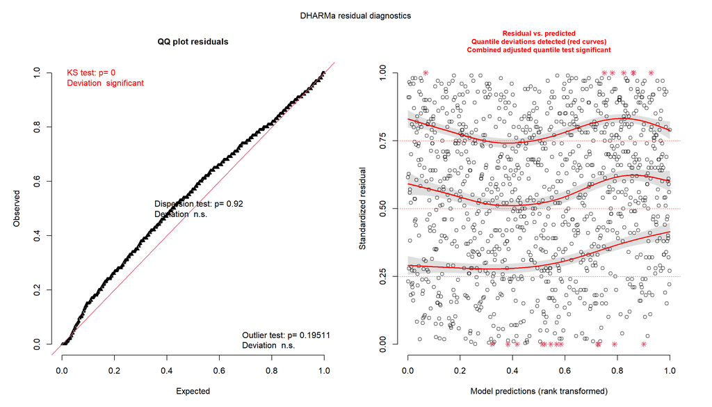

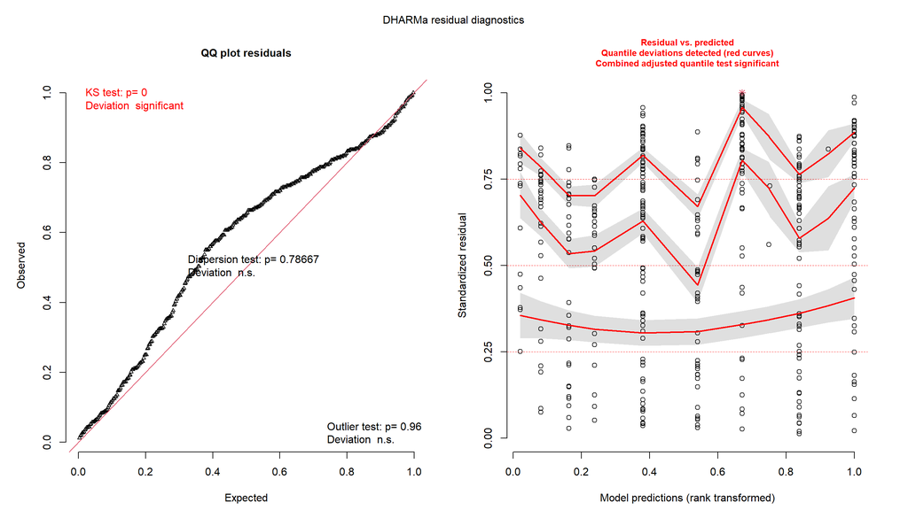

Figure 4.2: DHARMa Residual plots for the updated calibration model when irec is zero - model does not include irec as explanatory variable

## 4.1 Questions for discussion:

- The alternative model performs better than others we explored, but diagnostics indicate that there is room for improvement.
- The use of an adjacency matrix to explain the effect of region (or the finer scale area), would likely lead to improved model fits.